# Unsupervised_Learning_Project

```python
import numpy             as np
import pandas            as pd
import scipy.stats       as stats
import seaborn           as sns
import matplotlib.pyplot as plt
import plotly.express    as px

%matplotlib inline

from sklearn.model_selection  import train_test_split
from sklearn.model_selection import GridSearchCV
from sklearn.preprocessing import LabelEncoder
from sklearn.model_selection import cross_val_score
from sklearn.linear_model import LogisticRegression
from sklearn.cluster import KMeans
from sklearn.decomposition import PCA
from sklearn.svm import SVC
from sklearn.naive_bayes import GaussianNB
from sklearn import preprocessing
from sklearn import metrics

from scipy.spatial.distance import cdist
from scipy.stats import zscore
```

### Part A - 30 Marks

STEPS AND TASK [30 Marks]:

1. Data Understanding & Exploration: [5 Marks]

A. Read ‘Car name.csv’ as a DataFrame and assign it to a variable. [1 Mark]

```python
df_car_name = pd.read_csv('Car name.csv')
```

```python
df_car_name.head()
```

|  | car_name |
| --- | --- |
| 0 | chevrolet chevelle malibu |
| 1 | buick skylark 320 |
| 2 | plymouth satellite |
| 3 | amc rebel sst |
| 4 | ford torino |

```python
df_car_name.shape
```

```
(398, 1)
```

```python
df_car_name.columns
```

```
Index(['car_name'], dtype='object')
```

```python
df_car_name.info()
```

```
<class 'pandas.core.frame.DataFrame'>
RangeIndex: 398 entries, 0 to 397
Data columns (total 1 columns):
 #   Column    Non-Null Count  Dtype
---  ------    --------------  -----
 0   car_name  398 non-null    object
dtypes: object(1)
memory usage: 3.2+ KB
```

```python
df_car_name.count()
```

```
car_name    398
dtype: int64
```

```python
df_car_name.describe()
```

|  | car_name |
| --- | --- |
| count | 398 |
| unique | 305 |
| top | ford pinto |
| freq | 6 |

```python
df_car_name.nunique()
```

```
car_name    305
dtype: int64
```

```python
df_car_name.dtypes
```

```
car_name    object
dtype: object
```

B. Read ‘Car-Attributes.json as a DataFrame and assign it to a variable. [1 Mark]

```python
df_car_attributes = pd.read_json('Car-Attributes.json')
```

```python
df_car_attributes.head()
```

|  | mpg | cyl | disp | hp | wt | acc | yr | origin |
| --- | --- | --- | --- | --- | --- | --- | --- | --- |
| 0 | 18.0 | 8 | 307.0 | 130 | 3504 | 12.0 | 70 | 1 |
| 1 | 15.0 | 8 | 350.0 | 165 | 3693 | 11.5 | 70 | 1 |
| 2 | 18.0 | 8 | 318.0 | 150 | 3436 | 11.0 | 70 | 1 |
| 3 | 16.0 | 8 | 304.0 | 150 | 3433 | 12.0 | 70 | 1 |
| 4 | 17.0 | 8 | 302.0 | 140 | 3449 | 10.5 | 70 | 1 |

```python
df_car_attributes.shape
```

```
(398, 8)
```

```python
df_car_attributes.columns
```

```
Index(['mpg', 'cyl', 'disp', 'hp', 'wt', 'acc', 'yr', 'origin'], dtype='object')
```

```python
df_car_attributes.info()
```

```
<class 'pandas.core.frame.DataFrame'>
RangeIndex: 398 entries, 0 to 397
Data columns (total 8 columns):
 #   Column  Non-Null Count  Dtype
---  ------  --------------  -----
 0   mpg     398 non-null    float64
 1   cyl     398 non-null    int64
 2   disp    398 non-null    float64
 3   hp      398 non-null    object
 4   wt      398 non-null    int64
 5   acc     398 non-null    float64
 6   yr      398 non-null    int64
 7   origin  398 non-null    int64
dtypes: float64(3), int64(4), object(1)
memory usage: 25.0+ KB
```

```python
df_car_attributes.count()
```

```
mpg       398
cyl       398
disp      398
hp        398
wt        398
acc       398
yr        398
origin    398
dtype: int64
```

```python
df_car_attributes.describe()
```

|  | mpg | cyl | disp | wt | acc | yr | origin |
| --- | --- | --- | --- | --- | --- | --- | --- |
| count | 398.000000 | 398.000000 | 398.000000 | 398.000000 | 398.000000 | 398.000000 | 398.000000 |
| mean | 23.514573 | 5.454774 | 193.425879 | 2970.424623 | 15.568090 | 76.010050 | 1.572864 |
| std | 7.815984 | 1.701004 | 104.269838 | 846.841774 | 2.757689 | 3.697627 | 0.802055 |
| min | 9.000000 | 3.000000 | 68.000000 | 1613.000000 | 8.000000 | 70.000000 | 1.000000 |
| 25% | 17.500000 | 4.000000 | 104.250000 | 2223.750000 | 13.825000 | 73.000000 | 1.000000 |
| 50% | 23.000000 | 4.000000 | 148.500000 | 2803.500000 | 15.500000 | 76.000000 | 1.000000 |
| 75% | 29.000000 | 8.000000 | 262.000000 | 3608.000000 | 17.175000 | 79.000000 | 2.000000 |
| max | 46.600000 | 8.000000 | 455.000000 | 5140.000000 | 24.800000 | 82.000000 | 3.000000 |

```python
df_car_attributes.nunique()
```

```
mpg       129
cyl         5
disp       82
hp         94
wt        351
acc        95
yr         13
origin      3
dtype: int64
```

```python
df_car_attributes.dtypes
```

```
mpg       float64
cyl         int64
disp      float64
hp         object
wt          int64
acc       float64
yr          int64
origin      int64
dtype: object
```

C. Merge both the DataFrames together to form a single DataFrame [2 Mark]

```python
df_merged = pd.concat([df_car_name, df_car_attributes], axis=1)
```

```python
df_merged.head()
```

|  | car_name | mpg | cyl | disp | hp | wt | acc | yr | origin |
| --- | --- | --- | --- | --- | --- | --- | --- | --- | --- |
| 0 | chevrolet chevelle malibu | 18.0 | 8 | 307.0 | 130 | 3504 | 12.0 | 70 | 1 |
| 1 | buick skylark 320 | 15.0 | 8 | 350.0 | 165 | 3693 | 11.5 | 70 | 1 |
| 2 | plymouth satellite | 18.0 | 8 | 318.0 | 150 | 3436 | 11.0 | 70 | 1 |
| 3 | amc rebel sst | 16.0 | 8 | 304.0 | 150 | 3433 | 12.0 | 70 | 1 |
| 4 | ford torino | 17.0 | 8 | 302.0 | 140 | 3449 | 10.5 | 70 | 1 |

```python
df_merged.shape
```

```
(398, 9)
```

```python
df_merged.columns
```

```
Index(['car_name', 'mpg', 'cyl', 'disp', 'hp', 'wt', 'acc', 'yr', 'origin'], dtype='object')
```

```python
df_merged.info()
```

```
<class 'pandas.core.frame.DataFrame'>
RangeIndex: 398 entries, 0 to 397
Data columns (total 9 columns):
 #   Column    Non-Null Count  Dtype
---  ------    --------------  -----
 0   car_name  398 non-null    object
 1   mpg       398 non-null    float64
 2   cyl       398 non-null    int64
 3   disp      398 non-null    float64
 4   hp        398 non-null    object
 5   wt        398 non-null    int64
 6   acc       398 non-null    float64
 7   yr        398 non-null    int64
 8   origin    398 non-null    int64
dtypes: float64(3), int64(4), object(2)
memory usage: 28.1+ KB
```

```python
df_merged.count()
```

```
car_name    398
mpg         398
cyl         398
disp        398
hp          398
wt          398
acc         398
yr          398
origin      398
dtype: int64
```

```python
df_merged.describe()
```

|  | mpg | cyl | disp | wt | acc | yr | origin |
| --- | --- | --- | --- | --- | --- | --- | --- |
| count | 398.000000 | 398.000000 | 398.000000 | 398.000000 | 398.000000 | 398.000000 | 398.000000 |
| mean | 23.514573 | 5.454774 | 193.425879 | 2970.424623 | 15.568090 | 76.010050 | 1.572864 |
| std | 7.815984 | 1.701004 | 104.269838 | 846.841774 | 2.757689 | 3.697627 | 0.802055 |
| min | 9.000000 | 3.000000 | 68.000000 | 1613.000000 | 8.000000 | 70.000000 | 1.000000 |
| 25% | 17.500000 | 4.000000 | 104.250000 | 2223.750000 | 13.825000 | 73.000000 | 1.000000 |
| 50% | 23.000000 | 4.000000 | 148.500000 | 2803.500000 | 15.500000 | 76.000000 | 1.000000 |
| 75% | 29.000000 | 8.000000 | 262.000000 | 3608.000000 | 17.175000 | 79.000000 | 2.000000 |
| max | 46.600000 | 8.000000 | 455.000000 | 5140.000000 | 24.800000 | 82.000000 | 3.000000 |

```python
df_merged.nunique()
```

```
car_name    305
mpg         129
cyl           5
disp         82
hp           94
wt          351
acc          95
yr           13
origin        3
dtype: int64
```

```python
df_merged.dtypes
```

```
car_name     object
mpg         float64
cyl           int64
disp        float64
hp           object
wt            int64
acc         float64
yr            int64
origin        int64
dtype: object
```

D. Print 5 point summary of the numerical features and share insights. [1 Marks]

Descriptive Statistics involves understanding the distribution and nature of the data. Five number summary is a part of descriptive statistics and consists of five values and all these values will help us to describe the data.

```
- The minimum value (the lowest value)
- 25th Percentile or Q1
- 50th Percentile or Q2 or Median
- 75th Percentile or Q3
- Maximum Value (the highest value)
```

```python
df_merged.describe()[3:].T
```

|  | min | 25% | 50% | 75% | max |
| --- | --- | --- | --- | --- | --- |
| mpg | 9.0 | 17.500 | 23.0 | 29.000 | 46.6 |
| cyl | 3.0 | 4.000 | 4.0 | 8.000 | 8.0 |
| disp | 68.0 | 104.250 | 148.5 | 262.000 | 455.0 |
| wt | 1613.0 | 2223.750 | 2803.5 | 3608.000 | 5140.0 |
| acc | 8.0 | 13.825 | 15.5 | 17.175 | 24.8 |
| yr | 70.0 | 73.000 | 76.0 | 79.000 | 82.0 |
| origin | 1.0 | 1.000 | 1.0 | 2.000 | 3.0 |

1. Data Preparation & Analysis: [10 Marks]

A. Check and print feature-wise percentage of missing values present in the data and impute with the best suitable approach. [2 Mark]

```python
df_merged.isnull().sum()
```

```
car_name    0
mpg         0
cyl         0
disp        0
hp          0
wt          0
acc         0
yr          0
origin      0
dtype: int64
```

```python
df_merged.isna().sum()
```

```
car_name    0
mpg         0
cyl         0
disp        0
hp          0
wt          0
acc         0
yr          0
origin      0
dtype: int64
```

```python
df_merged['hp'].unique()
```

```
array([130, 165, 150, 140, 198, 220, 215, 225, 190, 170, 160, 95, 97, 85,
       88, 46, 87, 90, 113, 200, 210, 193, '?', 100, 105, 175, 153, 180,
       110, 72, 86, 70, 76, 65, 69, 60, 80, 54, 208, 155, 112, 92, 145,
       137, 158, 167, 94, 107, 230, 49, 75, 91, 122, 67, 83, 78, 52, 61,
       93, 148, 129, 96, 71, 98, 115, 53, 81, 79, 120, 152, 102, 108, 68,
       58, 149, 89, 63, 48, 66, 139, 103, 125, 133, 138, 135, 142, 77, 62,
       132, 84, 64, 74, 116, 82], dtype=object)
```

```python
df_merged[df_merged['hp'].str.isnumeric() == False]
```

|  | car_name | mpg | cyl | disp | hp | wt | acc | yr | origin |
| --- | --- | --- | --- | --- | --- | --- | --- | --- | --- |
| 32 | ford pinto | 25.0 | 4 | 98.0 | ? | 2046 | 19.0 | 71 | 1 |
| 126 | ford maverick | 21.0 | 6 | 200.0 | ? | 2875 | 17.0 | 74 | 1 |
| 330 | renault lecar deluxe | 40.9 | 4 | 85.0 | ? | 1835 | 17.3 | 80 | 2 |
| 336 | ford mustang cobra | 23.6 | 4 | 140.0 | ? | 2905 | 14.3 | 80 | 1 |
| 354 | renault 18i | 34.5 | 4 | 100.0 | ? | 2320 | 15.8 | 81 | 2 |
| 374 | amc concord dl | 23.0 | 4 | 151.0 | ? | 3035 | 20.5 | 82 | 1 |

```python
df_merged[df_merged['hp'] == '?']
```

|  | car_name | mpg | cyl | disp | hp | wt | acc | yr | origin |
| --- | --- | --- | --- | --- | --- | --- | --- | --- | --- |
| 32 | ford pinto | 25.0 | 4 | 98.0 | ? | 2046 | 19.0 | 71 | 1 |
| 126 | ford maverick | 21.0 | 6 | 200.0 | ? | 2875 | 17.0 | 74 | 1 |
| 330 | renault lecar deluxe | 40.9 | 4 | 85.0 | ? | 1835 | 17.3 | 80 | 2 |
| 336 | ford mustang cobra | 23.6 | 4 | 140.0 | ? | 2905 | 14.3 | 80 | 1 |
| 354 | renault 18i | 34.5 | 4 | 100.0 | ? | 2320 | 15.8 | 81 | 2 |
| 374 | amc concord dl | 23.0 | 4 | 151.0 | ? | 3035 | 20.5 | 82 | 1 |

- We could see that there are 6 datapoints where the hp has non numberic value of question mark. Lets impute this first with the most appropriate values.

```python
# Replace missing values with NaN

df_merged = df_merged.replace('?', np.nan)
```

```python
df_merged['hp'].isnull().sum()
```

```
6
```

```python
df_merged.median()
```

```
C:\Users\Bhavya Govindrao\AppData\Local\Temp\ipykernel_6432\2733465149.py:1: FutureWarning: The default value of numeric_only in DataFrame.median is deprecated. In a future version, it will default to False. In addition, specifying 'numeric_only=None' is deprecated. Select only valid columns or spec…
  df_merged.median()
```

```
mpg         23.0
cyl          4.0
disp       148.5
hp          93.5
wt        2803.5
acc         15.5
yr          76.0
origin       1.0
dtype: float64
```

```python
# Replace hp with median

df_merged['hp'].fillna((df_merged['hp'].median()), inplace = True)
```

```python
df_merged['hp'].isnull().sum()
```

```
0
```

```python
df_merged['hp'].unique()
```

```
array([130. , 165. , 150. , 140. , 198. , 220. , 215. , 225. , 190. ,
       170. , 160. ,  95. ,  97. ,  85. ,  88. ,  46. ,  87. ,  90. ,
       113. , 200. , 210. , 193. ,  93.5, 100. , 105. , 175. , 153. ,
       180. , 110. ,  72. ,  86. ,  70. ,  76. ,  65. ,  69. ,  60. ,
        80. ,  54. , 208. , 155. , 112. ,  92. , 145. , 137. , 158. ,
       167. ,  94. , 107. , 230. ,  49. ,  75. ,  91. , 122. ,  67. ,
        83. ,  78. ,  52. ,  61. ,  93. , 148. , 129. ,  96. ,  71. ,
        98. , 115. ,  53. ,  81. ,  79. , 120. , 152. , 102. , 108. ,
        68. ,  58. , 149. ,  89. ,  63. ,  48. ,  66. , 139. , 103. ,
       125. , 133. , 138. , 135. , 142. ,  77. ,  62. , 132. ,  84. ,
        64. ,  74. , 116. ,  82. ])
```

B. Check for duplicate values in the data and impute with the best suitable approach. [1 Mark]

```python
df_merged.duplicated().sum()
```

```
0
```

- No dulicates in the car dataframe

```python
df_merged['origin'].unique()
```

```
array([1, 3, 2], dtype=int64)
```

```python
# Update origin value with 1 to america, 2 to europe and 3 to asia

df_merged['origin'] = df_merged['origin'].replace({1: 'america', 2: 'europe', 3: 'asia'})
df_merged.head()
```

|  | car_name | mpg | cyl | disp | hp | wt | acc | yr | origin |
| --- | --- | --- | --- | --- | --- | --- | --- | --- | --- |
| 0 | chevrolet chevelle malibu | 18.0 | 8 | 307.0 | 130.0 | 3504 | 12.0 | 70 | america |
| 1 | buick skylark 320 | 15.0 | 8 | 350.0 | 165.0 | 3693 | 11.5 | 70 | america |
| 2 | plymouth satellite | 18.0 | 8 | 318.0 | 150.0 | 3436 | 11.0 | 70 | america |
| 3 | amc rebel sst | 16.0 | 8 | 304.0 | 150.0 | 3433 | 12.0 | 70 | america |
| 4 | ford torino | 17.0 | 8 | 302.0 | 140.0 | 3449 | 10.5 | 70 | america |

```python
df_merged['mpg'].unique()
```

```
array([18. , 15. , 16. , 17. , 14. , 24. , 22. , 21. , 27. , 26. , 25. ,
       10. , 11. ,  9. , 28. , 19. , 12. , 13. , 23. , 30. , 31. , 35. ,
       20. , 29. , 32. , 33. , 17.5, 15.5, 14.5, 22.5, 24.5, 18.5, 29.5,
       26.5, 16.5, 31.5, 36. , 25.5, 33.5, 20.5, 30.5, 21.5, 43.1, 36.1,
       32.8, 39.4, 19.9, 19.4, 20.2, 19.2, 25.1, 20.6, 20.8, 18.6, 18.1,
       17.7, 27.5, 27.2, 30.9, 21.1, 23.2, 23.8, 23.9, 20.3, 21.6, 16.2,
       19.8, 22.3, 17.6, 18.2, 16.9, 31.9, 34.1, 35.7, 27.4, 25.4, 34.2,
       34.5, 31.8, 37.3, 28.4, 28.8, 26.8, 41.5, 38.1, 32.1, 37.2, 26.4,
       24.3, 19.1, 34.3, 29.8, 31.3, 37. , 32.2, 46.6, 27.9, 40.8, 44.3,
       43.4, 36.4, 44.6, 40.9, 33.8, 32.7, 23.7, 23.6, 32.4, 26.6, 25.8,
       23.5, 39.1, 39. , 35.1, 32.3, 37.7, 34.7, 34.4, 29.9, 33.7, 32.9,
       31.6, 28.1, 30.7, 24.2, 22.4, 34. , 38. , 44. ])
```

```python
# creating mpg_level column using the 25% and 75% of mpg values( <  17 as low, > 17 and < 29 as medium, > 29 as high  )

df_merged['mpg_level'] = df_merged['mpg'].apply(lambda x: 'low' if x < 17 else 'high' if x > 29 else 'medium')
df_merged.head()
```

|  | car_name | mpg | cyl | disp | hp | wt | acc | yr | origin | mpg_level |
| --- | --- | --- | --- | --- | --- | --- | --- | --- | --- | --- |
| 0 | chevrolet chevelle malibu | 18.0 | 8 | 307.0 | 130.0 | 3504 | 12.0 | 70 | america | medium |
| 1 | buick skylark 320 | 15.0 | 8 | 350.0 | 165.0 | 3693 | 11.5 | 70 | america | low |
| 2 | plymouth satellite | 18.0 | 8 | 318.0 | 150.0 | 3436 | 11.0 | 70 | america | medium |
| 3 | amc rebel sst | 16.0 | 8 | 304.0 | 150.0 | 3433 | 12.0 | 70 | america | low |
| 4 | ford torino | 17.0 | 8 | 302.0 | 140.0 | 3449 | 10.5 | 70 | america | medium |

```python
df_merged['cyl'].unique()
```

```
array([8, 4, 6, 3, 5], dtype=int64)
```

```python
df_merged['yr'].unique()
```

```
array([70, 71, 72, 73, 74, 75, 76, 77, 78, 79, 80, 81, 82], dtype=int64)
```

```python
df_merged.head()
```

|  | car_name | mpg | cyl | disp | hp | wt | acc | yr | origin | mpg_level |
| --- | --- | --- | --- | --- | --- | --- | --- | --- | --- | --- |
| 0 | chevrolet chevelle malibu | 18.0 | 8 | 307.0 | 130.0 | 3504 | 12.0 | 70 | america | medium |
| 1 | buick skylark 320 | 15.0 | 8 | 350.0 | 165.0 | 3693 | 11.5 | 70 | america | low |
| 2 | plymouth satellite | 18.0 | 8 | 318.0 | 150.0 | 3436 | 11.0 | 70 | america | medium |
| 3 | amc rebel sst | 16.0 | 8 | 304.0 | 150.0 | 3433 | 12.0 | 70 | america | low |
| 4 | ford torino | 17.0 | 8 | 302.0 | 140.0 | 3449 | 10.5 | 70 | america | medium |

```python
# List of categorical variables

df_categorical = df_merged.iloc[:, [2, 7, 8, 9]]
df_categorical.head()
```

|  | cyl | yr | origin | mpg_level |
| --- | --- | --- | --- | --- |
| 0 | 8 | 70 | america | medium |
| 1 | 8 | 70 | america | low |
| 2 | 8 | 70 | america | medium |
| 3 | 8 | 70 | america | low |
| 4 | 8 | 70 | america | medium |

```python
# List of numerical variables

df_numerical = df_merged.drop(['car_name', 'cyl', 'yr', 'origin', 'mpg_level'], axis = 1)
df_numerical.head()
```

|  | mpg | disp | hp | wt | acc |
| --- | --- | --- | --- | --- | --- |
| 0 | 18.0 | 307.0 | 130.0 | 3504 | 12.0 |
| 1 | 15.0 | 350.0 | 165.0 | 3693 | 11.5 |
| 2 | 18.0 | 318.0 | 150.0 | 3436 | 11.0 |
| 3 | 16.0 | 304.0 | 150.0 | 3433 | 12.0 |
| 4 | 17.0 | 302.0 | 140.0 | 3449 | 10.5 |

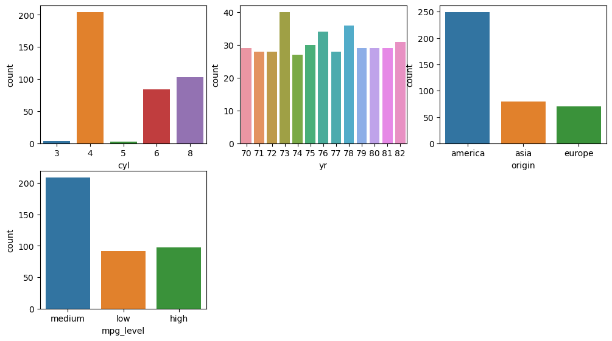

```python
# Plotting categorical variables

plt.figure(figsize = (12, 10))
col = 1
for i in df_categorical.columns:
    plt.subplot(3, 3, col)
    sns.countplot(x = i, data = df_categorical)
    col += 1
```

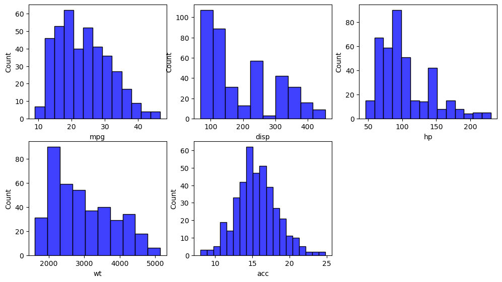

```python
# Plotting numerical variables

plt.figure(figsize = (12, 10))
col = 1
for i in df_numerical.columns:
    plt.subplot(3, 3, col)
    sns.histplot(df_numerical[i], color = 'b')
    col += 1
```

```
C:\Users\Bhavya Govindrao\AppData\Local\Temp\ipykernel_6432\1108538980.py:4: FutureWarning: The default value of numeric_only in DataFrame.corr is deprecated. In a future version, it will default to False. Select only valid columns or specify the value of numeric_only to silence this warning.
  corr = df_categorical.corr()
```

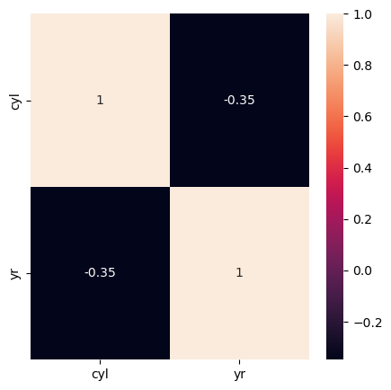

```python
# Checking for categorical correlation

plt.figure(figsize = (5, 5))
corr = df_categorical.corr()
sns.heatmap(corr, annot = True);
```

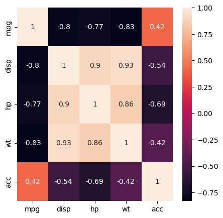

```python
# Checking for numerical correlation

plt.figure(figsize = (5, 5))
corr = df_numerical.corr()
sns.heatmap(corr, annot = True);
```

```
C:\Users\Bhavya Govindrao\AppData\Local\Temp\ipykernel_6432\3787672606.py:4: FutureWarning: The default value of numeric_only in DataFrame.corr is deprecated. In a future version, it will default to False. Select only valid columns or specify the value of numeric_only to silence this warning.
  corr = df_merged.corr()
```

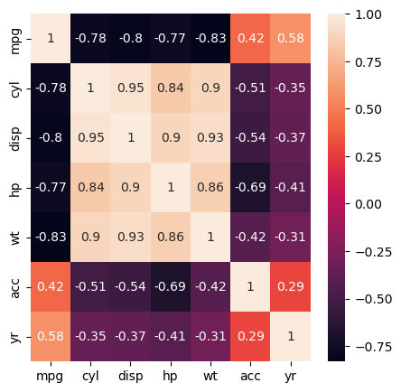

```python
# Checking for correlation

plt.figure(figsize = (5, 5))
corr = df_merged.corr()
sns.heatmap(corr, annot = True);
```

C. Plot a pairplot for all features. [1 Marks]

```python
df_merged.head()
```

|  | car_name | mpg | cyl | disp | hp | wt | acc | yr | origin | mpg_level |
| --- | --- | --- | --- | --- | --- | --- | --- | --- | --- | --- |
| 0 | chevrolet chevelle malibu | 18.0 | 8 | 307.0 | 130.0 | 3504 | 12.0 | 70 | america | medium |
| 1 | buick skylark 320 | 15.0 | 8 | 350.0 | 165.0 | 3693 | 11.5 | 70 | america | low |
| 2 | plymouth satellite | 18.0 | 8 | 318.0 | 150.0 | 3436 | 11.0 | 70 | america | medium |
| 3 | amc rebel sst | 16.0 | 8 | 304.0 | 150.0 | 3433 | 12.0 | 70 | america | low |
| 4 | ford torino | 17.0 | 8 | 302.0 | 140.0 | 3449 | 10.5 | 70 | america | medium |

```python
df_dummies = df_merged.drop(['car_name'], axis = 1)

df_dummies = pd.get_dummies(df_merged, columns=['origin'])
df_dummies = pd.get_dummies(df_merged, columns=['mpg_level'])
df_dummies.head()
```

|  | car_name | mpg | cyl | disp | hp | wt | acc | yr | origin | mpg_level_high | mpg_level_low | mpg_level_medium |
| --- | --- | --- | --- | --- | --- | --- | --- | --- | --- | --- | --- | --- |
| 0 | chevrolet chevelle malibu | 18.0 | 8 | 307.0 | 130.0 | 3504 | 12.0 | 70 | america | 0 | 0 | 1 |
| 1 | buick skylark 320 | 15.0 | 8 | 350.0 | 165.0 | 3693 | 11.5 | 70 | america | 0 | 1 | 0 |
| 2 | plymouth satellite | 18.0 | 8 | 318.0 | 150.0 | 3436 | 11.0 | 70 | america | 0 | 0 | 1 |
| 3 | amc rebel sst | 16.0 | 8 | 304.0 | 150.0 | 3433 | 12.0 | 70 | america | 0 | 1 | 0 |
| 4 | ford torino | 17.0 | 8 | 302.0 | 140.0 | 3449 | 10.5 | 70 | america | 0 | 0 | 1 |

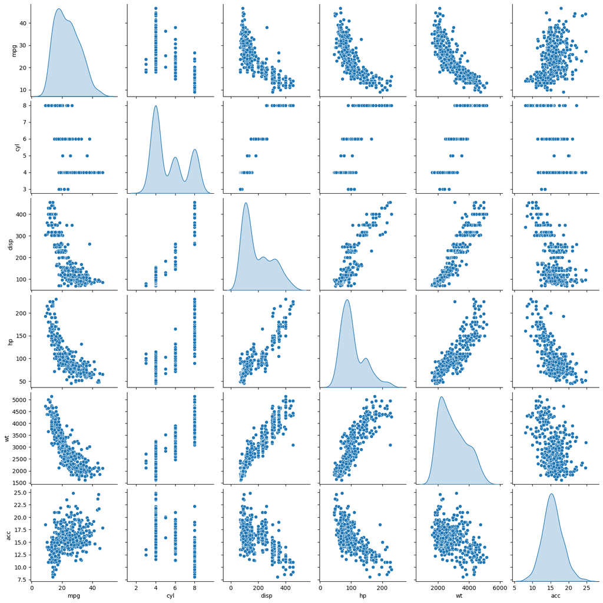

```python
# pair plot for the all numerical attributes

df_attr = df_dummies.iloc[:, 0:7]
sns.pairplot(df_attr, diag_kind = 'kde');
```

D. Visualize a scatterplot for ‘wt’ and ‘disp’. Datapoints should be distinguishable by ‘cyl’. [1 Marks]

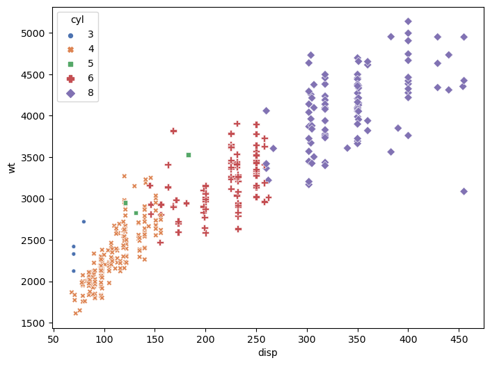

```python
plt.figure(figsize = (8, 6))
sns.scatterplot(x = "disp", y = "wt", hue = "cyl", data = df_merged, style = 'cyl', palette = "deep", size = 'cyl');
plt.show()
```

E. Share insights for Q2.d. [1 Marks]

- As the weight of the vehicle increases displacement of the engine increases
- The vehicles with more number of cylinders has higher displacement and more weight

F. Visualize a scatterplot for ‘wt’ and ’mpg’. Datapoints should be distinguishable by ‘cyl’. [1 Marks]

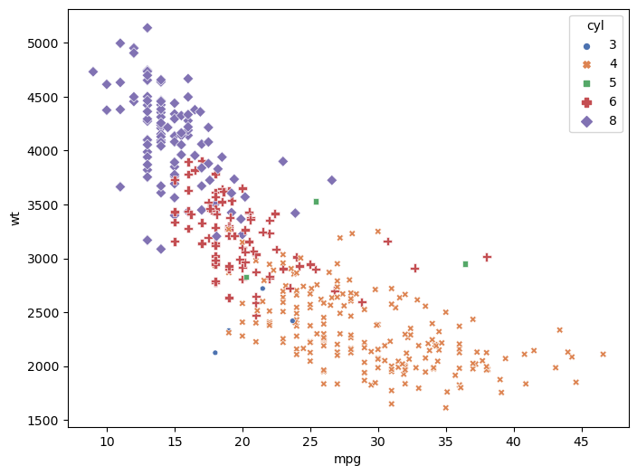

```python
plt.figure(figsize = (8, 6))
sns.scatterplot(x = "mpg", y = "wt", hue = "cyl", data = df_merged, style = 'cyl', palette = "deep", size = 'cyl');
plt.show()
```

G. Share insights for Q2.f. [1 Marks]

- As weight of the vehicle increases mpg drops
- Vehicles having more number of cylinders has lower mpg

H. Check for unexpected values in all the features and datapoints with such values. [2 Marks]

[Hint: ‘?’ is present in ‘hp’]

```python
df_merged_copy = pd.concat([df_car_name, df_car_attributes], axis=1)
df_merged_copy.head()
```

|  | car_name | mpg | cyl | disp | hp | wt | acc | yr | origin |
| --- | --- | --- | --- | --- | --- | --- | --- | --- | --- |
| 0 | chevrolet chevelle malibu | 18.0 | 8 | 307.0 | 130 | 3504 | 12.0 | 70 | 1 |
| 1 | buick skylark 320 | 15.0 | 8 | 350.0 | 165 | 3693 | 11.5 | 70 | 1 |
| 2 | plymouth satellite | 18.0 | 8 | 318.0 | 150 | 3436 | 11.0 | 70 | 1 |
| 3 | amc rebel sst | 16.0 | 8 | 304.0 | 150 | 3433 | 12.0 | 70 | 1 |
| 4 | ford torino | 17.0 | 8 | 302.0 | 140 | 3449 | 10.5 | 70 | 1 |

```python
df_merged_copy['hp'].unique()
```

```
array([130, 165, 150, 140, 198, 220, 215, 225, 190, 170, 160, 95, 97, 85,
       88, 46, 87, 90, 113, 200, 210, 193, '?', 100, 105, 175, 153, 180,
       110, 72, 86, 70, 76, 65, 69, 60, 80, 54, 208, 155, 112, 92, 145,
       137, 158, 167, 94, 107, 230, 49, 75, 91, 122, 67, 83, 78, 52, 61,
       93, 148, 129, 96, 71, 98, 115, 53, 81, 79, 120, 152, 102, 108, 68,
       58, 149, 89, 63, 48, 66, 139, 103, 125, 133, 138, 135, 142, 77, 62,
       132, 84, 64, 74, 116, 82], dtype=object)
```

```python
df_merged_copy[df_merged_copy['hp'].str.isnumeric() == False]
```

|  | car_name | mpg | cyl | disp | hp | wt | acc | yr | origin |
| --- | --- | --- | --- | --- | --- | --- | --- | --- | --- |
| 32 | ford pinto | 25.0 | 4 | 98.0 | ? | 2046 | 19.0 | 71 | 1 |
| 126 | ford maverick | 21.0 | 6 | 200.0 | ? | 2875 | 17.0 | 74 | 1 |
| 330 | renault lecar deluxe | 40.9 | 4 | 85.0 | ? | 1835 | 17.3 | 80 | 2 |
| 336 | ford mustang cobra | 23.6 | 4 | 140.0 | ? | 2905 | 14.3 | 80 | 1 |
| 354 | renault 18i | 34.5 | 4 | 100.0 | ? | 2320 | 15.8 | 81 | 2 |
| 374 | amc concord dl | 23.0 | 4 | 151.0 | ? | 3035 | 20.5 | 82 | 1 |

```python
df_merged_copy[df_merged_copy['hp'] == '?']
```

|  | car_name | mpg | cyl | disp | hp | wt | acc | yr | origin |
| --- | --- | --- | --- | --- | --- | --- | --- | --- | --- |
| 32 | ford pinto | 25.0 | 4 | 98.0 | ? | 2046 | 19.0 | 71 | 1 |
| 126 | ford maverick | 21.0 | 6 | 200.0 | ? | 2875 | 17.0 | 74 | 1 |
| 330 | renault lecar deluxe | 40.9 | 4 | 85.0 | ? | 1835 | 17.3 | 80 | 2 |
| 336 | ford mustang cobra | 23.6 | 4 | 140.0 | ? | 2905 | 14.3 | 80 | 1 |
| 354 | renault 18i | 34.5 | 4 | 100.0 | ? | 2320 | 15.8 | 81 | 2 |
| 374 | amc concord dl | 23.0 | 4 | 151.0 | ? | 3035 | 20.5 | 82 | 1 |

- We could see that there are 6 datapoints where the hp has non numberic value of question mark. Lets impute this first with the most appropriate values.

```python
# Replace missing values with NaN

df_merged_copy = df_merged_copy.replace('?', np.nan)
```

```python
df_merged_copy['hp'].isnull().sum()
```

```
6
```

```python
df_merged_copy.median()
```

```
C:\Users\Bhavya Govindrao\AppData\Local\Temp\ipykernel_6432\2076179829.py:1: FutureWarning: The default value of numeric_only in DataFrame.median is deprecated. In a future version, it will default to False. In addition, specifying 'numeric_only=None' is deprecated. Select only valid columns or spec…
  df_merged_copy.median()
```

```
mpg         23.0
cyl          4.0
disp       148.5
hp          93.5
wt        2803.5
acc         15.5
yr          76.0
origin       1.0
dtype: float64
```

```python
# Replace hp with median

df_merged_copy['hp'].fillna((df_merged_copy['hp'].median()), inplace = True)
```

```python
df_merged_copy['hp'].isnull().sum()
```

```
0
```

```python
df_merged_copy['hp'].unique()
```

```
array([130. , 165. , 150. , 140. , 198. , 220. , 215. , 225. , 190. ,
       170. , 160. ,  95. ,  97. ,  85. ,  88. ,  46. ,  87. ,  90. ,
       113. , 200. , 210. , 193. ,  93.5, 100. , 105. , 175. , 153. ,
       180. , 110. ,  72. ,  86. ,  70. ,  76. ,  65. ,  69. ,  60. ,
        80. ,  54. , 208. , 155. , 112. ,  92. , 145. , 137. , 158. ,
       167. ,  94. , 107. , 230. ,  49. ,  75. ,  91. , 122. ,  67. ,
        83. ,  78. ,  52. ,  61. ,  93. , 148. , 129. ,  96. ,  71. ,
        98. , 115. ,  53. ,  81. ,  79. , 120. , 152. , 102. , 108. ,
        68. ,  58. , 149. ,  89. ,  63. ,  48. ,  66. , 139. , 103. ,
       125. , 133. , 138. , 135. , 142. ,  77. ,  62. , 132. ,  84. ,
        64. ,  74. , 116. ,  82. ])
```

1. Clustering: [15 Marks]

A. Apply K-Means clustering for 2 to 10 clusters. [3 Marks]

```python
df_merged.dtypes
```

```
car_name      object
mpg          float64
cyl            int64
disp         float64
hp           float64
wt             int64
acc          float64
yr             int64
origin        object
mpg_level     object
dtype: object
```

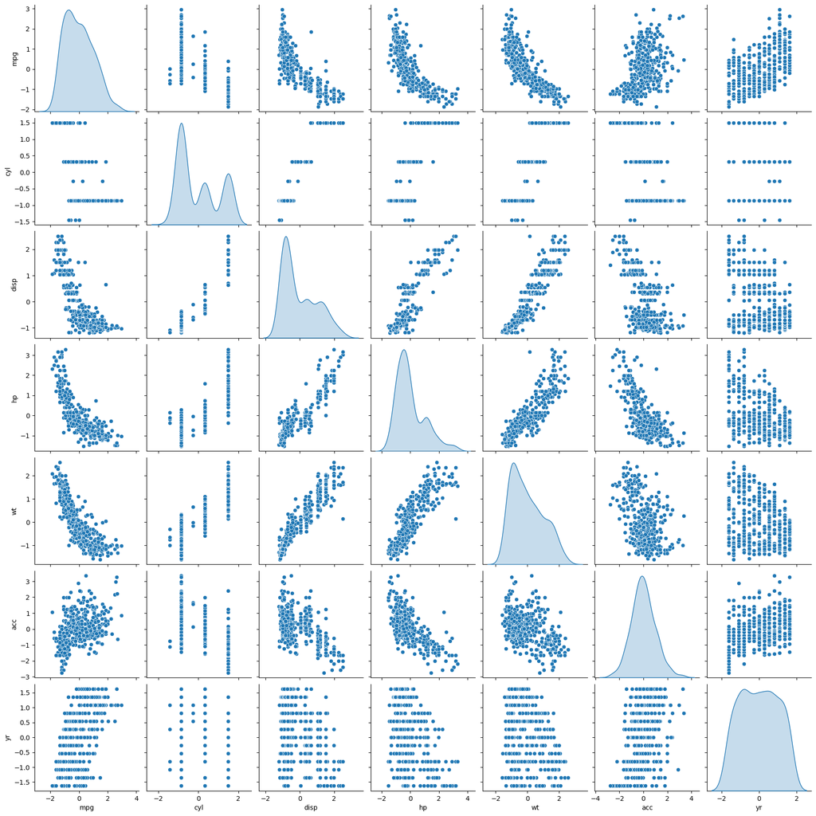

```python
mergedAttr = df_merged.iloc[:, 1:8]
df_merged_scaled = mergedAttr.apply(zscore)
sns.pairplot(df_merged_scaled, diag_kind = 'kde')
```

```python
# Finding optimal no. of clusters

cluster_range = range(2, 11)
meanDistortions = []
cluster_errors = []

for k in cluster_range:
    model = KMeans(n_clusters = k, n_init = 5)
    model.fit(df_merged_scaled)

    labels = model.labels_
    centroids = model.cluster_centers_
    cluster_errors.append(model.inertia_)

    prediction = model.predict(df_merged_scaled)
    meanDistortions.append(sum(np.min(cdist(df_merged_scaled, model.cluster_centers_, 'euclidean'), axis = 1)) / df_merged_scaled.shape[0])

clusters_df = pd.DataFrame({"num_clusters": cluster_range, "cluster_errors": cluster_errors})
clusters_df
```

[output not shown]

|  | num_clusters | cluster_errors |
| --- | --- | --- |
| 0 | 2 | 1294.841895 |
| 1 | 3 | 946.019791 |
| 2 | 4 | 738.392328 |
| 3 | 5 | 664.889003 |
| 4 | 6 | 599.388004 |
| 5 | 7 | 546.016080 |
| 6 | 8 | 499.339530 |
| 7 | 9 | 463.197424 |
| 8 | 10 | 428.898607 |

B. Plot a visual and find elbow point. [2 Marks]

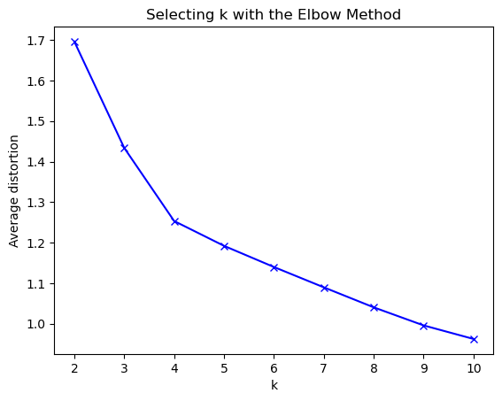

```python
plt.plot(cluster_range, meanDistortions, 'bx-')
plt.xlabel('k')
plt.ylabel('Average distortion')
plt.title('Selecting k with the Elbow Method')
```

- We could see the bend at 4, so let us create 4 custers

C. On the above visual, highlight which are the possible Elbow points. [1 Marks]

The curve looks like an elbow. In the above plot, the elbow bend at k = 4 (i.e., the Sum of squared distances falls suddenly), indicating the optimal k for this dataset and possible elbow point is 4.

D. Train a K-means clustering model once again on the optimal number of clusters. [3 Marks]

```python
meanDistortions = []
cluster_errors = []

model = KMeans(n_clusters = 4, n_init = 5)
model.fit(df_merged_scaled)
```

```
C:\Users\Bhavya Govindrao\anaconda3\lib\site-packages\sklearn\cluster\_kmeans.py:1382: UserWarning: KMeans is known to have a memory leak on Windows with MKL, when there are less chunks than available threads. You can avoid it by setting the environment variable OMP_NUM_THREADS=2.
  warnings.warn(
```

```
KMeans(n_clusters=4, n_init=5)
```

```python
# Check the number of data in each cluster

labels = model.labels_
counts = np.bincount(labels[labels>=0])
print(counts)
```

```
[114  94  91  99]
```

```python
# let us check the centers in each group

centroids = model.cluster_centers_
clusters_df = pd.DataFrame(centroids, columns = list(df_merged_scaled))
clusters_df.transpose()
```

|  | 0 | 1 | 2 | 3 |
| --- | --- | --- | --- | --- |
| mpg | 1.180173 | -1.163797 | -0.496827 | 0.202711 |
| cyl | -0.825340 | 1.498191 | 0.424430 | -0.862266 |
| disp | -0.781645 | 1.503923 | 0.305303 | -0.808523 |
| hp | -0.740517 | 1.521683 | -0.037758 | -0.557407 |
| wt | -0.768570 | 1.404098 | 0.337765 | -0.758636 |
| acc | 0.374983 | -1.086149 | 0.293670 | 0.329555 |
| yr | 1.101793 | -0.688324 | 0.032986 | -0.645492 |

E. Add a new feature in the DataFrame which will have labels based upon cluster value. [2 Marks]

```python
# Let us consider K = 4 as the elbow point is 4

final_model = KMeans(n_clusters = 4, n_init = 5)
final_model.fit(df_merged_scaled)
prediction = final_model.predict(df_merged_scaled)

# Append the prediction
df_merged["GROUP"] = prediction
print("Groups Assigned : \n")
df_merged.head()
```

```
C:\Users\Bhavya Govindrao\anaconda3\lib\site-packages\sklearn\cluster\_kmeans.py:1382: UserWarning: KMeans is known to have a memory leak on Windows with MKL, when there are less chunks than available threads. You can avoid it by setting the environment variable OMP_NUM_THREADS=2.
  warnings.warn(
```

```
Groups Assigned :
```

|  | car_name | mpg | cyl | disp | hp | wt | acc | yr | origin | mpg_level | GROUP |
| --- | --- | --- | --- | --- | --- | --- | --- | --- | --- | --- | --- |
| 0 | chevrolet chevelle malibu | 18.0 | 8 | 307.0 | 130.0 | 3504 | 12.0 | 70 | america | medium | 3 |
| 1 | buick skylark 320 | 15.0 | 8 | 350.0 | 165.0 | 3693 | 11.5 | 70 | america | low | 3 |
| 2 | plymouth satellite | 18.0 | 8 | 318.0 | 150.0 | 3436 | 11.0 | 70 | america | medium | 3 |
| 3 | amc rebel sst | 16.0 | 8 | 304.0 | 150.0 | 3433 | 12.0 | 70 | america | low | 3 |
| 4 | ford torino | 17.0 | 8 | 302.0 | 140.0 | 3449 | 10.5 | 70 | america | medium | 3 |

```python
df_merged_scaled["GROUP"] = prediction
print("Groups Assigned : \n")
df_merged_scaled.head()
```

```
Groups Assigned :
```

|  | mpg | cyl | disp | hp | wt | acc | yr | GROUP |
| --- | --- | --- | --- | --- | --- | --- | --- | --- |
| 0 | -0.706439 | 1.498191 | 1.090604 | 0.673118 | 0.630870 | -1.295498 | -1.627426 | 3 |
| 1 | -1.090751 | 1.498191 | 1.503514 | 1.589958 | 0.854333 | -1.477038 | -1.627426 | 3 |
| 2 | -0.706439 | 1.498191 | 1.196232 | 1.197027 | 0.550470 | -1.658577 | -1.627426 | 3 |
| 3 | -0.962647 | 1.498191 | 1.061796 | 1.197027 | 0.546923 | -1.295498 | -1.627426 | 3 |
| 4 | -0.834543 | 1.498191 | 1.042591 | 0.935072 | 0.565841 | -1.840117 | -1.627426 | 3 |

```python
df_merged['GROUP'].unique()
```

```
array([3, 0, 1, 2])
```

```python
df_merged_scaled['GROUP'].unique()
```

```
array([3, 0, 1, 2])
```

```python
mergedClust = df_merged.groupby(['GROUP'])
mergedClust.mean()
```

```
C:\Users\Bhavya Govindrao\AppData\Local\Temp\ipykernel_6432\958780146.py:2: FutureWarning: The default value of numeric_only in DataFrameGroupBy.mean is deprecated. In a future version, numeric_only will default to False. Either specify numeric_only or select only columns which should be valid for t…
  mergedClust.mean()
```

| GROUP | mpg | cyl | disp | hp | wt | acc | yr |
| --- | --- | --- | --- | --- | --- | --- | --- |
| 0 | 25.056436 | 4.009901 | 110.420792 | 83.143564 | 2335.821782 | 16.450495 | 73.633663 |
| 1 | 19.621111 | 6.177778 | 225.511111 | 103.005556 | 3262.855556 | 16.392222 | 76.200000 |
| 2 | 32.794690 | 4.053097 | 111.778761 | 75.929204 | 2316.849558 | 16.611504 | 80.097345 |
| 3 | 14.429787 | 8.000000 | 350.042553 | 162.393617 | 4157.978723 | 12.576596 | 73.468085 |

```python
mergedClustScaled = df_merged_scaled.groupby(['GROUP'])
mergedClustScaled.mean()
```

| GROUP | mpg | cyl | disp | hp | wt | acc | yr |
| --- | --- | --- | --- | --- | --- | --- | --- |
| 0 | 0.197519 | -0.850493 | -0.797062 | -0.554308 | -0.750319 | 0.320382 | -0.643488 |
| 1 | -0.498768 | 0.425580 | 0.308101 | -0.034014 | 0.345754 | 0.299225 | 0.051435 |
| 2 | 1.188820 | -0.825066 | -0.784022 | -0.743291 | -0.772751 | 0.378842 | 1.106775 |
| 3 | -1.163797 | 1.498191 | 1.503923 | 1.521683 | 1.404098 | -1.086149 | -0.688324 |

F. Plot a visual and color the datapoints based upon clusters. [2 Marks]

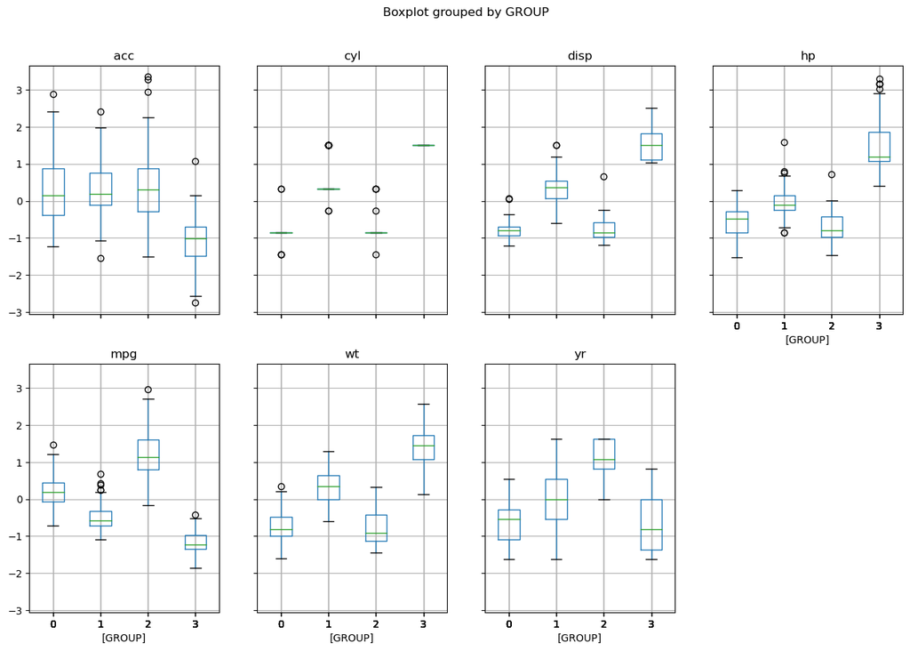

```python
df_merged_scaled.boxplot(by = 'GROUP', layout = (2, 4), figsize = (15, 10))
plt.show()
```

G. Pass a new DataPoint and predict which cluster it belongs to. [2 Marks]

```python
# Let us pass new datapoint with K = 5

final_model = KMeans(n_clusters = 5, n_init = 5)
final_model.fit(df_merged_scaled)
prediction = final_model.predict(df_merged_scaled)
```

```
C:\Users\Bhavya Govindrao\anaconda3\lib\site-packages\sklearn\cluster\_kmeans.py:1382: UserWarning: KMeans is known to have a memory leak on Windows with MKL, when there are less chunks than available threads. You can avoid it by setting the environment variable OMP_NUM_THREADS=2.
  warnings.warn(
```

```python
# Append the prediction

df_merged["GROUP"] = prediction
df_merged_scaled["GROUP"] = prediction
print("Groups Assigned : \n")
df_merged.head()
```

```
Groups Assigned :
```

|  | car_name | mpg | cyl | disp | hp | wt | acc | yr | origin | mpg_level | GROUP |
| --- | --- | --- | --- | --- | --- | --- | --- | --- | --- | --- | --- |
| 0 | chevrolet chevelle malibu | 18.0 | 8 | 307.0 | 130.0 | 3504 | 12.0 | 70 | america | medium | 0 |
| 1 | buick skylark 320 | 15.0 | 8 | 350.0 | 165.0 | 3693 | 11.5 | 70 | america | low | 4 |
| 2 | plymouth satellite | 18.0 | 8 | 318.0 | 150.0 | 3436 | 11.0 | 70 | america | medium | 0 |
| 3 | amc rebel sst | 16.0 | 8 | 304.0 | 150.0 | 3433 | 12.0 | 70 | america | low | 0 |
| 4 | ford torino | 17.0 | 8 | 302.0 | 140.0 | 3449 | 10.5 | 70 | america | medium | 0 |

```python
df_merged['GROUP'].unique()
```

```
array([0, 4, 2, 3, 1])
```

```python
df_merged_scaled['GROUP'].unique()
```

```
array([0, 4, 2, 3, 1])
```

```python
mergedClust = df_merged.groupby(['GROUP'])
mergedClust.mean()
```

```
C:\Users\Bhavya Govindrao\AppData\Local\Temp\ipykernel_6432\958780146.py:2: FutureWarning: The default value of numeric_only in DataFrameGroupBy.mean is deprecated. In a future version, numeric_only will default to False. Either specify numeric_only or select only columns which should be valid for t…
  mergedClust.mean()
```

| GROUP | mpg | cyl | disp | hp | wt | acc | yr |
| --- | --- | --- | --- | --- | --- | --- | --- |
| 0 | 15.031667 | 8.000000 | 326.116667 | 147.316667 | 4059.700000 | 13.340000 | 74.450000 |
| 1 | 32.794690 | 4.053097 | 111.778761 | 75.929204 | 2316.849558 | 16.611504 | 80.097345 |
| 2 | 25.056436 | 4.009901 | 110.420792 | 83.143564 | 2335.821782 | 16.450495 | 73.633663 |
| 3 | 19.621111 | 6.177778 | 225.511111 | 103.005556 | 3262.855556 | 16.392222 | 76.200000 |
| 4 | 13.367647 | 8.000000 | 392.264706 | 189.000000 | 4331.411765 | 11.229412 | 71.735294 |

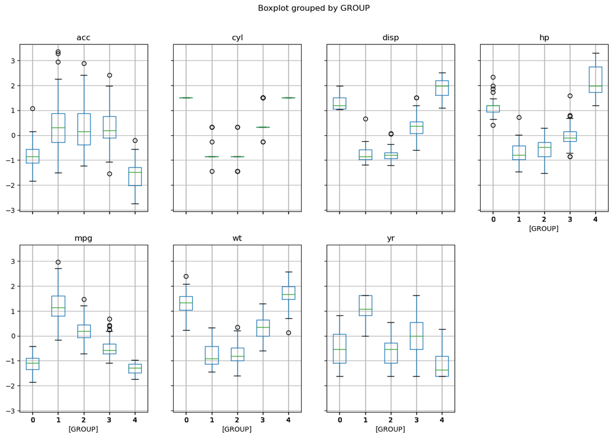

```python
df_merged_scaled.boxplot(by = 'GROUP', layout = (2, 4), figsize = (15, 10))
plt.show()
```

### Part B - 30 Marks

STEPS AND TASK [30 Marks]:

1. Data Understanding & Cleaning: [5 Marks]

A. Read ‘vehicle.csv’ and save as DataFrame. [1 Marks]

```python
df_vehicle = pd.read_csv('vehicle.csv')
```

```python
df_vehicle.head()
```

|  | compactness | circularity | distance_circularity | radius_ratio | pr.axis_aspect_ratio | max.length_aspect_ratio | scatter_ratio | elongatedness | pr.axis_rectangularity | max.length_rectangularity | scaled_variance | scaled_variance.1 | scaled_radius_of_gyration | scaled_radius_of_gyration.1 | skewness_about | skewness_about.1 | skewness_about.2 | hollows_ratio | class |
| --- | --- | --- | --- | --- | --- | --- | --- | --- | --- | --- | --- | --- | --- | --- | --- | --- | --- | --- | --- |
| 0 | 95 | 48.0 | 83.0 | 178.0 | 72.0 | 10 | 162.0 | 42.0 | 20.0 | 159 | 176.0 | 379.0 | 184.0 | 70.0 | 6.0 | 16.0 | 187.0 | 197 | van |
| 1 | 91 | 41.0 | 84.0 | 141.0 | 57.0 | 9 | 149.0 | 45.0 | 19.0 | 143 | 170.0 | 330.0 | 158.0 | 72.0 | 9.0 | 14.0 | 189.0 | 199 | van |
| 2 | 104 | 50.0 | 106.0 | 209.0 | 66.0 | 10 | 207.0 | 32.0 | 23.0 | 158 | 223.0 | 635.0 | 220.0 | 73.0 | 14.0 | 9.0 | 188.0 | 196 | car |
| 3 | 93 | 41.0 | 82.0 | 159.0 | 63.0 | 9 | 144.0 | 46.0 | 19.0 | 143 | 160.0 | 309.0 | 127.0 | 63.0 | 6.0 | 10.0 | 199.0 | 207 | van |
| 4 | 85 | 44.0 | 70.0 | 205.0 | 103.0 | 52 | 149.0 | 45.0 | 19.0 | 144 | 241.0 | 325.0 | 188.0 | 127.0 | 9.0 | 11.0 | 180.0 | 183 | bus |

```python
df_vehicle.shape
```

```
(846, 19)
```

```python
df_vehicle.columns
```

```
Index(['compactness', 'circularity', 'distance_circularity', 'radius_ratio',
       'pr.axis_aspect_ratio', 'max.length_aspect_ratio', 'scatter_ratio',
       'elongatedness', 'pr.axis_rectangularity', 'max.length_rectangularity',
       'scaled_variance', 'scaled_variance.1', 'scaled_radius_of_gyration',
       'scaled_radius_of_gyration.1', 'skewness_about', 'skewness_about.1',
       'skewness_about.2', 'hollows_ratio', 'class'],
      dtype='object')
```

```python
df_vehicle.info()
```

```
<class 'pandas.core.frame.DataFrame'>
RangeIndex: 846 entries, 0 to 845
Data columns (total 19 columns):
 #   Column                       Non-Null Count  Dtype
---  ------                       --------------  -----
 0   compactness                  846 non-null    int64
 1   circularity                  841 non-null    float64
 2   distance_circularity         842 non-null    float64
 3   radius_ratio                 840 non-null    float64
 4   pr.axis_aspect_ratio         844 non-null    float64
 5   max.length_aspect_ratio      846 non-null    int64
 6   scatter_ratio                845 non-null    float64
 7   elongatedness                845 non-null    float64
 8   pr.axis_rectangularity       843 non-null    float64
 9   max.length_rectangularity    846 non-null    int64
 10  scaled_variance              843 non-null    float64
 11  scaled_variance.1            844 non-null    float64
 12  scaled_radius_of_gyration    844 non-null    float64
 13  scaled_radius_of_gyration.1  842 non-null    float64
 14  skewness_about               840 non-null    float64
 15  skewness_about.1             845 non-null    float64
 16  skewness_about.2             845 non-null    float64
 17  hollows_ratio                846 non-null    int64
 18  class                        846 non-null    object
dtypes: float64(14), int64(4), object(1)
memory usage: 125.7+ KB
```

```python
df_vehicle.count()
```

```
compactness                    846
circularity                    841
distance_circularity           842
radius_ratio                   840
pr.axis_aspect_ratio           844
max.length_aspect_ratio        846
scatter_ratio                  845
elongatedness                  845
pr.axis_rectangularity         843
max.length_rectangularity      846
scaled_variance                843
scaled_variance.1              844
scaled_radius_of_gyration      844
scaled_radius_of_gyration.1    842
skewness_about                 840
skewness_about.1               845
skewness_about.2               845
hollows_ratio                  846
class                          846
dtype: int64
```

```python
df_vehicle.describe()
```

|  | compactness | circularity | distance_circularity | radius_ratio | pr.axis_aspect_ratio | max.length_aspect_ratio | scatter_ratio | elongatedness | pr.axis_rectangularity | max.length_rectangularity | scaled_variance | scaled_variance.1 | scaled_radius_of_gyration | scaled_radius_of_gyration.1 | skewness_about | skewness_about.1 | skewness_about.2 | hollows_ratio |
| --- | --- | --- | --- | --- | --- | --- | --- | --- | --- | --- | --- | --- | --- | --- | --- | --- | --- | --- |
| count | 846.000000 | 841.000000 | 842.000000 | 840.000000 | 844.000000 | 846.000000 | 845.000000 | 845.000000 | 843.000000 | 846.000000 | 843.000000 | 844.000000 | 844.000000 | 842.000000 | 840.000000 | 845.000000 | 845.000000 | 846.000000 |
| mean | 93.678487 | 44.828775 | 82.110451 | 168.888095 | 61.678910 | 8.567376 | 168.901775 | 40.933728 | 20.582444 | 147.998818 | 188.631079 | 439.494076 | 174.709716 | 72.447743 | 6.364286 | 12.602367 | 188.919527 | 195.632388 |
| std | 8.234474 | 6.152172 | 15.778292 | 33.520198 | 7.891463 | 4.601217 | 33.214848 | 7.816186 | 2.592933 | 14.515652 | 31.411004 | 176.666903 | 32.584808 | 7.486190 | 4.920649 | 8.936081 | 6.155809 | 7.438797 |
| min | 73.000000 | 33.000000 | 40.000000 | 104.000000 | 47.000000 | 2.000000 | 112.000000 | 26.000000 | 17.000000 | 118.000000 | 130.000000 | 184.000000 | 109.000000 | 59.000000 | 0.000000 | 0.000000 | 176.000000 | 181.000000 |
| 25% | 87.000000 | 40.000000 | 70.000000 | 141.000000 | 57.000000 | 7.000000 | 147.000000 | 33.000000 | 19.000000 | 137.000000 | 167.000000 | 318.000000 | 149.000000 | 67.000000 | 2.000000 | 5.000000 | 184.000000 | 190.250000 |
| 50% | 93.000000 | 44.000000 | 80.000000 | 167.000000 | 61.000000 | 8.000000 | 157.000000 | 43.000000 | 20.000000 | 146.000000 | 179.000000 | 363.500000 | 173.500000 | 71.500000 | 6.000000 | 11.000000 | 188.000000 | 197.000000 |
| 75% | 100.000000 | 49.000000 | 98.000000 | 195.000000 | 65.000000 | 10.000000 | 198.000000 | 46.000000 | 23.000000 | 159.000000 | 217.000000 | 587.000000 | 198.000000 | 75.000000 | 9.000000 | 19.000000 | 193.000000 | 201.000000 |
| max | 119.000000 | 59.000000 | 112.000000 | 333.000000 | 138.000000 | 55.000000 | 265.000000 | 61.000000 | 29.000000 | 188.000000 | 320.000000 | 1018.000000 | 268.000000 | 135.000000 | 22.000000 | 41.000000 | 206.000000 | 211.000000 |

```python
df_vehicle.nunique()
```

```
compactness                     44
circularity                     27
distance_circularity            63
radius_ratio                   134
pr.axis_aspect_ratio            37
max.length_aspect_ratio         21
scatter_ratio                  131
elongatedness                   35
pr.axis_rectangularity          13
max.length_rectangularity       66
scaled_variance                128
scaled_variance.1              422
scaled_radius_of_gyration      143
scaled_radius_of_gyration.1     39
skewness_about                  23
skewness_about.1                41
skewness_about.2                30
hollows_ratio                   31
class                            3
dtype: int64
```

```python
df_vehicle.dtypes
```

```
compactness                      int64
circularity                    float64
distance_circularity           float64
radius_ratio                   float64
pr.axis_aspect_ratio           float64
max.length_aspect_ratio          int64
scatter_ratio                  float64
elongatedness                  float64
pr.axis_rectangularity         float64
max.length_rectangularity        int64
scaled_variance                float64
scaled_variance.1              float64
scaled_radius_of_gyration      float64
scaled_radius_of_gyration.1    float64
skewness_about                 float64
skewness_about.1               float64
skewness_about.2               float64
hollows_ratio                    int64
class                           object
dtype: object
```

B. Check percentage of missing values and impute with correct approach. [1 Marks]

```python
df_vehicle.isnull().sum()
```

```
compactness                    0
circularity                    5
distance_circularity           4
radius_ratio                   6
pr.axis_aspect_ratio           2
max.length_aspect_ratio        0
scatter_ratio                  1
elongatedness                  1
pr.axis_rectangularity         3
max.length_rectangularity      0
scaled_variance                3
scaled_variance.1              2
scaled_radius_of_gyration      2
scaled_radius_of_gyration.1    4
skewness_about                 6
skewness_about.1               1
skewness_about.2               1
hollows_ratio                  0
class                          0
dtype: int64
```

```python
df_vehicle.isna().sum()
```

```
compactness                    0
circularity                    5
distance_circularity           4
radius_ratio                   6
pr.axis_aspect_ratio           2
max.length_aspect_ratio        0
scatter_ratio                  1
elongatedness                  1
pr.axis_rectangularity         3
max.length_rectangularity      0
scaled_variance                3
scaled_variance.1              2
scaled_radius_of_gyration      2
scaled_radius_of_gyration.1    4
skewness_about                 6
skewness_about.1               1
skewness_about.2               1
hollows_ratio                  0
class                          0
dtype: int64
```

```python
#Replacing the missing values by median

for i in df_vehicle.columns[:18]:
    median_value = df_vehicle[i].median()
    df_vehicle[i] = df_vehicle[i].fillna(median_value)
```

```python
df_vehicle.isnull().sum()
```

```
compactness                    0
circularity                    0
distance_circularity           0
radius_ratio                   0
pr.axis_aspect_ratio           0
max.length_aspect_ratio        0
scatter_ratio                  0
elongatedness                  0
pr.axis_rectangularity         0
max.length_rectangularity      0
scaled_variance                0
scaled_variance.1              0
scaled_radius_of_gyration      0
scaled_radius_of_gyration.1    0
skewness_about                 0
skewness_about.1               0
skewness_about.2               0
hollows_ratio                  0
class                          0
dtype: int64
```

C. Visualize a Pie-chart and print percentage of values for variable ‘class’. [2 Marks]

```python
df_vehicle['class'].value_counts()
```

```
car    429
bus    218
van    199
Name: class, dtype: int64
```

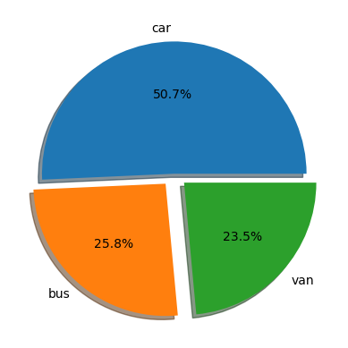

```python
plt.pie(df_vehicle['class'].value_counts(), explode = (0, 0.1, 0.1), labels = ['car','bus','van'], autopct = '%1.1f%%', shadow = True)
plt.show()
```

D. Check for duplicate rows in the data and impute with correct approach. [1 Marks]

```python
df_vehicle.duplicated().sum()
```

```
0
```

- No dulicates in the vehicle dataframe
1. Data Preparation: [2 Marks]

A. Split data into X and Y. [Train and Test optional] [1 Marks]

```python
df_vehicle.shape
```

```
(846, 19)
```

```python
# independent and dependent variables

X = df_vehicle.iloc[:, 0:18]
y = df_vehicle.iloc[:, 18]
```

```python
# Split X and y into training and test set in 70:30 ratio
X_train, X_test, y_train, y_test = train_test_split(X, y, test_size = 0.3, random_state = 10)
```

B. Standardize the Data. [1 Marks]

```python
scaler = preprocessing.StandardScaler().fit(X_train)
X_train_scaled = scaler.transform(X_train)
```

```python
scaler = preprocessing.StandardScaler().fit(X_test)
X_test_scaled = scaler.transform(X_test)
```

1. Model Building: [13 Marks]

A. Train a base Classification model using SVM. [1 Marks]

```python
model = SVC()
model.fit(X_train_scaled, y_train)
prediction = model.predict(X_test_scaled)
```

B. Print Classification metrics for train data. [1 Marks]

```python
# Check the accuracy on the training data
print('Accuracy on Training data: ', model.score(X_train, y_train))

# Check the accuracy on the testing data
print('Accuracy on Testing data: ', model.score(X_test, y_test))

# Calculate the recall value
print('Recall value: ', metrics.recall_score(y_test, prediction, average = 'macro'))

# Calculate the precision value
print('Precision value: ', metrics.precision_score(y_test, prediction, average = 'macro'))
```

```
Accuracy on Training data:  0.5135135135135135
Accuracy on Testing data:  0.4921259842519685
Recall value:  0.9615016998542982
Precision value:  0.9485878855444073
```

```
C:\Users\Bhavya Govindrao\anaconda3\lib\site-packages\sklearn\base.py:413: UserWarning: X has feature names, but SVC was fitted without feature names
  warnings.warn(
C:\Users\Bhavya Govindrao\anaconda3\lib\site-packages\sklearn\base.py:413: UserWarning: X has feature names, but SVC was fitted without feature names
  warnings.warn(
```

```python
print("Confusion Matrix:\n", metrics.confusion_matrix(prediction, y_test))
```

```
Confusion Matrix:
 [[ 68   1   0]
 [  1 118   1]
 [  2   6  57]]
```

```python
print("Classification Report:\n", metrics.classification_report(prediction, y_test))
```

```
Classification Report:
               precision    recall  f1-score   support

         bus       0.96      0.99      0.97        69
         car       0.94      0.98      0.96       120
         van       0.98      0.88      0.93        65

    accuracy                           0.96       254
   macro avg       0.96      0.95      0.95       254
weighted avg       0.96      0.96      0.96       254
```

C. Apply PCA on the data with 10 components. [3 Marks]

```python
#Based on the plot, we will select 10 components
pca = PCA(n_components = 10)
pca.fit(X_train_scaled)

#Assign the components to the X variable
X_train_scaled = pca.transform(X_train_scaled)
```

D. Visualize Cumulative Variance Explained with Number of Components. [2 Marks]

```python
np.cumsum(pca.explained_variance_ratio_)
```

```
array([0.52318974, 0.68666982, 0.7967591 , 0.86115571, 0.91329949,
       0.94160568, 0.96073039, 0.97309202, 0.98167263, 0.98681636])
```

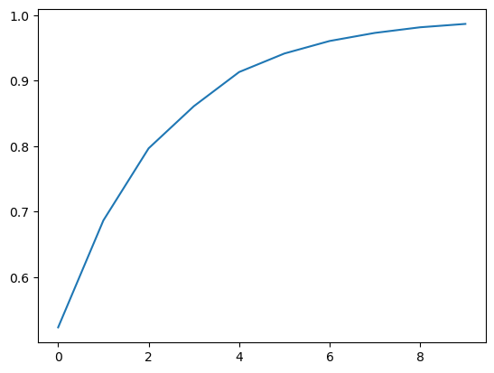

```python
plt.plot(np.cumsum(pca.explained_variance_ratio_))
plt.show()
```

E. Draw a horizontal line on the above plot to highlight the threshold of 90%. [1 Marks]

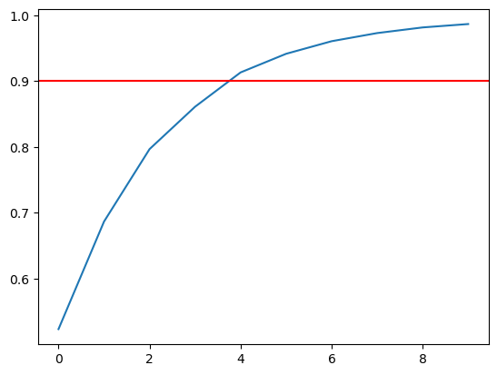

```python
plt.plot(np.cumsum(pca.explained_variance_ratio_))
plt.axhline(y = 0.9, color = 'r', linestyle = '-')
plt.show()
```

F. Apply PCA on the data. This time Select Minimum Components with 90% or above variance explained. [2 Marks]

```python
pca = PCA(0.90)
pca.fit(X_train)

#Assign the components to the X variable
# X_train_scaled = pca.transform(X_train_scaled)
```

```
PCA(n_components=0.9)
```

G. Train SVM model on components selected from above step. [1 Marks]

```python
model = SVC()
model.fit(X_train, y_train)
```

```
SVC()
```

```python
prediction = model.predict(X_test)
```

H. Print Classification metrics for train data of above model and share insights. [2 Marks]

```python
# Check the accuracy on the training data
print('Accuracy on Training data: ', model.score(X_train, y_train))

# Check the accuracy on the testing data
print('Accuracy on Testing data: ', model.score(X_test, y_test))

# Calculate the recall value
print('Recall value: ', metrics.recall_score(y_test, prediction, average = 'macro'))

# Calculate the precision value
print('Precision value: ', metrics.precision_score(y_test, prediction, average = 'macro'))
```

```
Accuracy on Training data:  0.6858108108108109
Accuracy on Testing data:  0.6496062992125984
Recall value:  0.6178261291889267
Precision value:  0.6190530058177117
```

```python
print("Confusion Matrix:\n", metrics.confusion_matrix(prediction, y_test))
```

```
Confusion Matrix:
 [[33  4 19]
 [31 96  3]
 [ 7 25 36]]
```

```python
print("Classification Report:\n", metrics.classification_report(prediction, y_test))
```

```
Classification Report:
               precision    recall  f1-score   support

         bus       0.46      0.59      0.52        56
         car       0.77      0.74      0.75       130
         van       0.62      0.53      0.57        68

    accuracy                           0.65       254
   macro avg       0.62      0.62      0.61       254
weighted avg       0.66      0.65      0.65       254
```

1. Performance Improvement: [5 Marks]